# Assignment 1

14119666

2024-11-11

# Participants’ Reaction Time in Different “Expectation-Target” Conditions.

## Upload packages and data

### Upload packages

Firstly, upload packages to run all kinds of functions we need

```r
#We use this package to tidy our data
library( tidyverse )

#We use this package to draw ridge plot
library( ggridges )

#We use this package to combine two plots together
library( patchwork )
```

### Upload raw data

```r
#"read_CSv( the address of the file)" can read the address of the file and upload it.
raw_data <- read_csv( "C:/Users/HUAWEI/Desktop/advanced data skills/assignment1/assignment_1_data.csv" )
```

## Data wrangling

### Count rows and columns

Next, check how many rows(participants) and columns are included

```r
#"ncol" is used to counting the number of columns this dataset has
ncol( raw_data )
```

```
## [1] 5
```

```r
#"nrow" is used to counting the number of rows this dataset has
nrow( raw_data )
```

```
## [1] 48
```

So there are 5 columns (ID, Condition1, Condition2, Condition3 and Condition4) and 48 participants.

### Filter

Then we need to check whether there is any missing data or duplicate IDs(participants)

```r
raw_data %>%

  #remove rows with missing (NA) values in specific column "()"
  filter(!is.na( Condition1 ) & !is.na( Condition2 ) & !is.na(Condition3 ) & !is.na(Condition4 )) %>%

  nrow()
```

```
## [1] 48
```

```r
raw_data %>%

  #remove duplicated rows
  distinct( ID ) %>%

  nrow()
```

```
## [1] 48
```

Now we know there is neither empty cells nor duplicate IDs in this data set.

### Rename

Then rename all conditions to make them easier and more meaningful to read.

```r
renamed_data <- raw_data %>%

  rename( N_N = Condition1, #Number and Number
        N_L = Condition2, #Number and Letter
        L_N = Condition3, #Letter and Number
        L_L = Condition4 ) #Letter and Letter
```

### longer_data

```r
#change renamed_data in to longer_data
longer_data <- renamed_data %>%

  #"pivot_longer" is used to change short date into longer data
  pivot_longer( cols = c( N_N, N_L, L_N, L_L ),
                names_to = "Condition",
                values_to = "RT")

#check whether the long_data is created as we expected, we use "head()" to see the first 6 rows in specific dataset
head( longer_data )
```

```
## # A tibble: 6 × 3
##      ID Condition    RT
##   <dbl> <chr>     <dbl>
## 1     1 N_N        1011
## 2     1 N_L        1218
## 3     1 L_N        1249
## 4     1 L_L         992
## 5     2 N_N         984
## 6     2 N_L        1223
```

## Data summary

Next, summary statistics for each of the 4 conditions. Format mean text and keep two decimal places, we will use these numbers as texts later.

```r
statistics_for_RT <-longer_data %>%

  #group RT in accordance with Condition
  group_by ( Condition ) %>%

  summarise ( mean_RT = mean( RT ),
              #calculating RT's mean and sd
              sd_RT = sd( RT )) %>%

  #build a new column in dataset "statistics_for_RT", the content of which are the text of means
  mutate ( mean_text = round( mean_RT, 2))

head(statistics_for_RT)
```

```
## # A tibble: 4 × 4
##   Condition mean_RT sd_RT mean_text
##   <chr>       <dbl> <dbl>     <dbl>
## 1 L_L          996.  29.7      996.
## 2 L_N         1252.  28.0     1252.
## 3 N_L         1246.  29.8     1246.
## 4 N_N          995.  26.5      995.
```

## Data visulization

### Ridge plot

I chose ridge plot because I think using this plot, the shape and distribution of each condition can be shown perfectly. To present this information more clearly and concisely, and also to condense essential details, I added a dashed line in the ridge plot to represent the mean value for each condition.

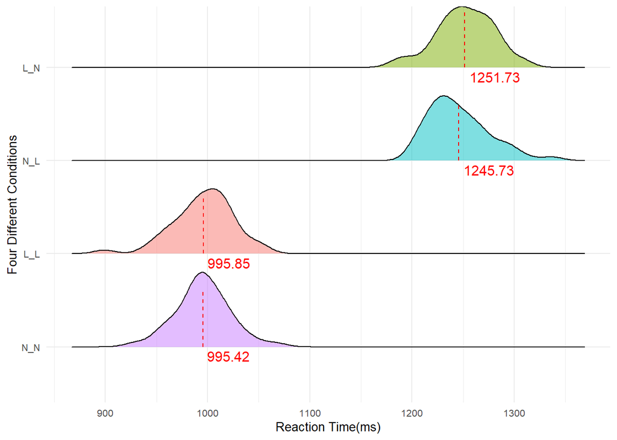

```r
longer_data %>%

  #"ggplot" is used to define the aesthetic mapping for the function, specifying the X and Y axes.
  ##"fct_reorder()" is applied to reorder the output based on specific conditions.
  ##"fill = ()" is used to add different colors according to the condition in "()"
  ggplot( aes ( x = RT,
                y = fct_reorder(Condition, RT, .fun = mean ),
                fill = Condition )) +

  #draw ridge plots with consistent units, making comparisons easy
  geom_density_ridges( scale = .8 , alpha = .5 ) +

  #add dashed mean lines in this plot for each conditions
  geom_segment ( data = statistics_for_RT,
                 aes ( x = mean_RT,
                       ##sets the ending x-coordinate at the same mean_RT value, so the line segment is vertical
                       xend = mean_RT,
                       ##"as.numeric" is used to converts the "condition" factor to a numeric value
                       y = as.numeric( fct_reorder( Condition, mean_RT )),
                       yend = as.numeric( fct_reorder( Condition, mean_RT )) + .6),
               ##add dash lines, the color is red and the width is 0.5
               linetype = "dashed", colour = "red", linewidth = .5) +

  #"geom_text()" is used to add the number of different means in four conditions into our plot
  geom_text( data = statistics_for_RT, aes( x = mean_RT,
                                            ###shift down
                                            y = as.numeric(fct_reorder( Condition, mean_RT )) - .1,
                                            ###specifies that we what to display the number of mean_RTs in different conditions
                                            label = mean_text ),
             ##"hjust" controls horizontal text position, this code here is used to shift 0.1 to the right for better appearance
             hjust = -.1, colour = "red", size = 4 ) +

  #to build a tidy background
  theme_minimal() +

  #In order to better comply with APA standards, we use "element_text()" to adjust the text formatting in the diagram
  ##"family = (sans)" means use sans font, "size = 10" means font size is 10px.
  theme( text = element_text ( family = "sans", size = 10 )) +

  #remove legend
  guides( fill = "none" ) +

  #Naming the x and y axes
  labs( x = "Reaction Time(ms)",
        y = "Four Different Conditions" )
```

As we observed,

①when both the expectation and target are numbers, participants responded faster, averaging 995.42 ms. When the expectation was a letter but the target was a number, response times were slowest, averaging 1251.73 ms;

②Responses were faster when the expectation matched the target than when they differed.

③When expectation and target were the same, responses were faster for numbers than for letters; when different, responses were quicker when numbers appeared first. However, the significance of this difference remains unclear.

### Line plot

Based on this information, we categorized reaction times into two groups, “Accordance” and “Contradiction”, by expectation-target congruency, and created line plots for further analysis.

Firstly, turn longer_data into two_condition_data.

```r
two_condition_data <- longer_data %>%

  #"mutate()" is used to build a new column or rename an existing column
  ##"case_when" here is used to creating two columns based on conditional choices
  ###"%in%" is used to Checking if Condition is "N_N" or "L_L". If it is, the expression returns TRUE, and this data will be recorded in the column at the right of "~".
  mutate( Condition = case_when( Condition %in% c( "N_N", "L_L" ) ~ "Accordance",
                                 Condition %in% c( "N_L", "L_N" ) ~ "Contradiction",
                                 TRUE ~ Condition ))
```

Then, plot the first line chart, “plot1”.

```r
plot1 <- two_condition_data %>%

  ggplot( aes( x = ID, y = RT,
              colour = Condition,
              group = Condition )) +

  #add data points
  geom_point( size = 2, alpha = .7 ) +

  #draw smooth line and remove confidence interval
  geom_smooth( se = FALSE ) +

  theme_minimal() +

  theme( text = element_text( family = "sans", size = 10 ),
         ##"legend position = ()" is used to putting legend within plot to conform to APA format requirements
         legend.position = c( 0.5, 0.5),
         ##adjust the location and format of legend
         plot.title = element_text( hjust = .5, face = "bold", size = 16)) +

  labs( x = "ID",
        y = "Reaction Time(ms)" )
```

Plot the second line chart, “plot2”

```r
plot2 <- longer_data %>%

  ggplot( aes( x = ID, y = RT,
               colour = Condition,
               group = Condition )) +

  geom_point( size = 2, alpha = .7 ) +

  geom_smooth( se = FALSE ) +

  theme_minimal() +

  theme( text = element_text( family = "sans", size = 10 ),
         legend.position = c( 0.5, 0.5),
         plot.title = element_text( hjust = .5, face = "bold", size = 16)) +

  labs( x = "ID",
        y = "Reaction Time(ms)" )
```

Finally, combine these two plots.

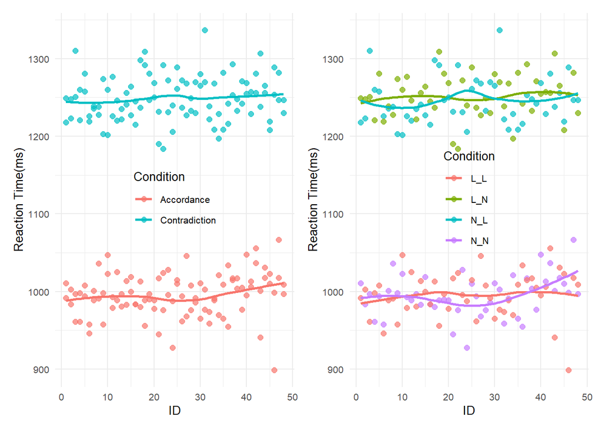

```r
#combine the two plots
combined_plot <- plot1 + plot2

#output the combined plot
print( combined_plot )
```

From the combined plot, we can observe the following:

①Reaction times vary across individuals for the same stimulus, with most responses clustering within a specific range.

②Reaction times appear shorter when expectation and target match compared to when they differ, although further analysis is needed to confirm the significance of this difference.

③Based on the distribution of points and line patterns, it’s unclear if the order or type of stimulus (number or letter) significantly impacts reaction time.

For further confirmation, a repeated measures ANOVA could be performed.